# Activision Blizzard Stock Time Series Analysis

# Conclusion

Our dataset contains 384 entries of Activision Blizzard Inc. (ATVI) daily stock data. We have set the frequency = 5 to match a Monday to Friday week.  
During the analysis of the plots for ATVI certain points of interest were observered in the Open/Close and Volume plots.  
In both the following plots the colored points represent points of interest. * Orange + October 2nd, 2018: the highest closing price of Activision Blizzard stock at 83.39. * Green + November 1st, 2018: the closing price of the stock prior to BlizzCon and the announcement of Diablo Immortals. * Red + November 9th: the day with the highest volume traded.

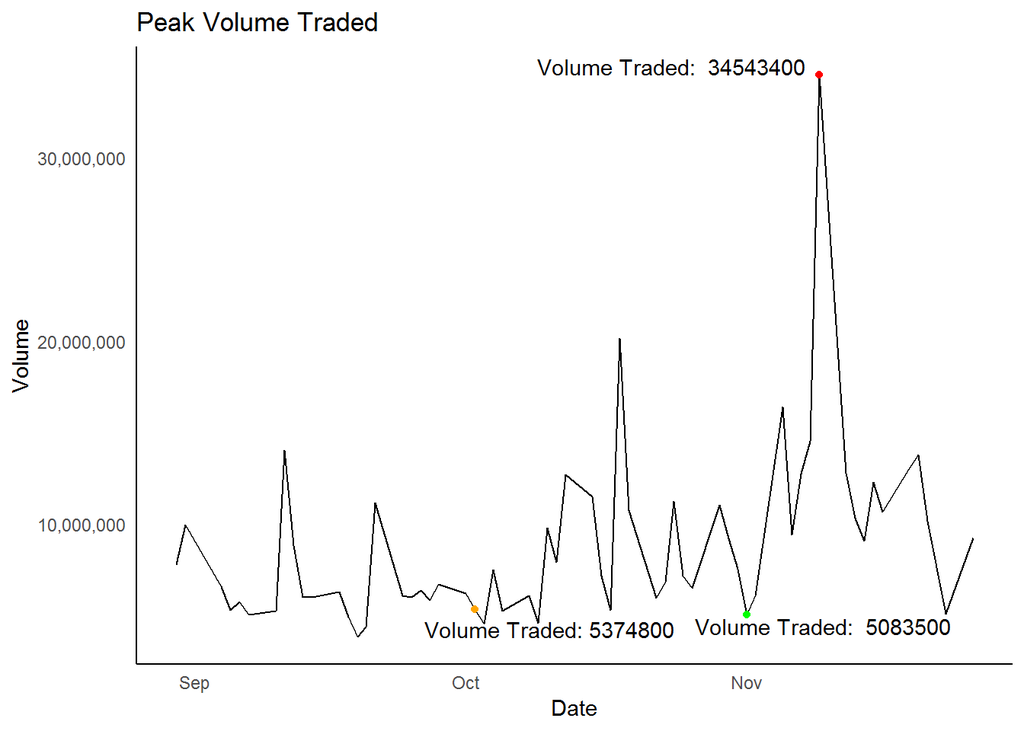

The volume traded on 2018-11-09(November 9th, 2018) was more than six times the volume traded one week prior.

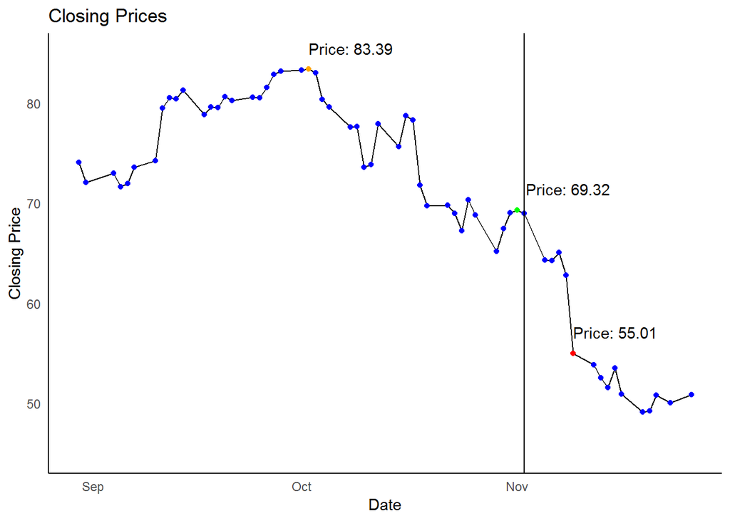

On October 2nd 2018 (orange point in the above plot), the highest ATVI stock was at an all time high closing price of 83.39 USD; however in the following days the stock would drop to 73.58 USD on October 10th before starting to rise again. On October 12th, Activision launched *Call of Duty: Black Ops 4*; the highly anticpated sequel to *Call of Duty: Black Ops 3*. Less than a week later on October 18th, Activsion announced that within the first three days of release that they have sold more than $500 million worldwide and that the release set records for digital sales across all platforms[^2]. However, investors were disappointed as this only matched the sales of *Black Ops 3* which implies flat sales growth over the year. Investors expected the release of *Black Ops 4* to capitalize on the popularity of “battle royale”" type games and result in bigger sales.

Exactly one week prior to November 9th (red point), Blizzard at their annual gaming convention, BlizzCon, was expected to announce a new release; many were hopeful for the next installment in their Diablo series, *Diablo 4*, but were instead disappointed with a release of a mobile game titled *Diablo: Immortal*. On the day of their announcement, Novemember 2nd, the stock price opened at 69.949997 and closed at 68.989998 very small decrease. However on the following Monday, November 5th, the stock price ended at 64.339996, this is a 5.38% decrease from the opening price of 68. Since the BlizzCon on November 2nd, as of November 29th the stock has dropped 24.9%.

## Forecasting

When training our model we took 80% of the dataset and used the remaining 20% to test the accuracy of the forecasts.

|  | ME | RMSE | MAE | MPE | MAPE |
| --- | --- | --- | --- | --- | --- |
| Test set | 9.714185 | 10.40043 | 9.714185 | 13.71713 | 13.71713 |
| Test set2 | 9.367425 | 10.06119 | 9.367425 | 13.22296 | 13.22296 |
| Test set1 | 9.834414 | 10.54824 | 9.834414 | 13.87919 | 13.87919 |

The following measures were used to test the accuracy of the models: mean error (ME), root-mean-square error (RMSE), mean absolute error (MAE), mean percentage error (MPE), and mean absolute percentage error (MAPE). The lower the measure the less error the model had in forecasting the correct values in the test set and thus should be a better model at forecasting future values. From our table, the HoltWinters exponential smoothing model performed the the best in forecasting the test set in every measure.

Looking at the Holtwinters forecast:

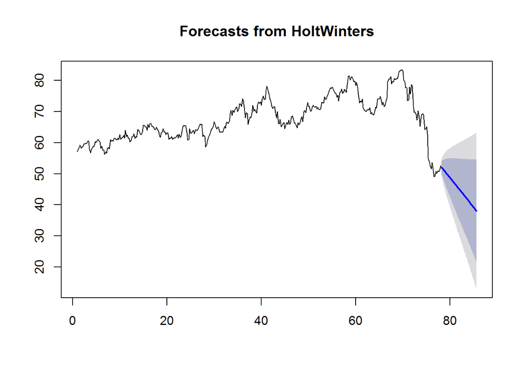

# References

[^1] Fuller, W. A. (1976). Introduction to Statistical Time Series. New York: John Wiley and Sons. ISBN 0-471-28715-6.

[^2] https://investor.activision.com/news-releases/news-release-details/call-duty-black-ops-4-delivers-over-half-billion-dollar-opening

https://docs.tibco.com/pub/enterprise-runtime-for-R/4.0.0/doc/html/Language_Reference/stats/HoltWinters.html